# Coursework Report

*N* removed NAs: 2

*N* removed typo: 1

*N* removed <18: 13

*N* total clean: 134

| Group | *N* | *M*<sub>age</sub> | *M*<sub>rating</sub> |
| --- | --- | --- | --- |
| Control | 71 | 20.6 | 6.98 |
| Experim | 63 | 20.5 | 5.72 |

**Main analysis results**

*t*(132) = 9.98, *p* < .001

[interactive chart not shown]

[figure not shown]

[interactive chart not shown]

# Coursework Report

Analysing Data, Spring 2020

# Methods

## Participants

Summary of Participant Demographics by Experimental Condition

[output not shown]

## Design

In this replication experiment of Elliot et al. (2010) the effect of the colour red on ratings of attractiveness is being examined, using white as a control condition. The independent variable of the experiment is whether the participant views the photograph on a red or white background. The dependent variable is the attractiveness ratings given by the participants after viewing the photograph, assessed using three items, on a scale from 1 (not at all attractive) to 9 (extremely attractive). The three items are the same as used in Elliot et al.’s (2010, p. 403) study: “How attractive do you think this person is?” “How pleasant is this person to look at?” and “If I were to meet the person in this picture face to face, I would think he is attractive.” The hypothesis for this experiment is that there will be significantly higher attractiveness ratings of the photograph for those in the red experimental condition, compared to those in the white control condition. This hypothesis is based on the results of Elliot et al.’s (2010) original experiment which found perceived attractiveness to be higher for the red condition. An independent *t*-test will be used to examine the influence of colour on attractiveness ratings, at a significance level of $\alpha$ = .05.

# Results

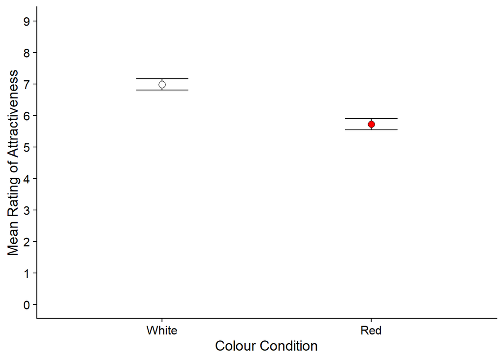

# Discussion

The results of this experiment show a significant difference between colour conditions, with the participants in the white control condition rating the photograph as significantly higher in attractiveness than the participants in the red experimental condition. These results therefore do not support the hypothesis, as the mean attractiveness rating was higher for the white condition rather than the red, which means there was no positive red effect. The data would however support a positive white effect on attractiveness ratings or possibly a negative red effect.

In order to make a conclusion of whether there is or isn’t a red effect, we would need to compare other similar studies’ outcomes. The results of other studies in this area are varied. Some provide significant evidence for a positive red effect (Elliot et al., 2010; Guéguen, 2012; Pazda et al., 2012; Wen et al., 2014), while others show a non-significant red effect (Elliot & Maier, 2013; Hesslinger et al., 2015) or, like my results, a white effect (Peperkoorn et al., 2016). It is also important to note that it is suggested by Francis (2013) that there may have been publication bias in Elliot et al.’s (2010) study. This is because a power analysis showed that “only 6.9 out of the 12 tests” (Francis, 2013, p. 294) would be expected to show a significant red effect, whereas Elliot et al. (2010) concluded a red effect on all tests. Thus, the research providing evidence for a red effect may be “too good to be true” (Francis, 2013, p. 295), which may explain why researchers, including myself, have failed to replicate these results.

The variation of results for these studies may be due the different samples used, for example in Experiment 1 of Elliot et al.’s (2010) original study there were only 21 female participants, while in the replication by Elliot and Maier (2013) there were 144 female participants. This could explain why Elliot et al. (2010) concluded there to be a significant red effect for women, while Elliot and Maier’s (2013) results did not show a significant red effect, even though the mean ratings of attractiveness were higher within the red condition.

Another potential issue with these past studies and the present replication is the use of self-report ratings, particularly the Likert Scale. Self-report techniques are susceptible to social desirability bias (Wen et al., 2014), however they are inexpensive to use and obtain data quickly and easily. The use of a biological measure would prevent this bias, but it would be more difficult to implicate.

Even though the results of this study show a significant white effect, and therefore do not support the hypothesised red effect, as the results from other studies are varied, an accurate conclusion cannot be made in my opinion. There needs to be more research, with large and diverse samples in order to make a more accurate conclusion to whether red significantly affects ratings of attractiveness. I would also suggest using a different study design in the future, as replications of the same study (Elliot et al., 2010), show different results, therefore this particular methodology may not be applicable for, or reliable at, assessing the possibility of a red effect on attractiveness ratings.

# References

Elliot, A. J., Niesta Kayser, D., Greitemeyer, T., Lichtenfeld, S., Gramzow, R. H., Maier, M. A., & Liu, H. (2010). Red, rank, and romance in women viewing men. *Journal of Experimental Psychology: General, 139*(3), 399-417.

Elliot, A. J., & Maier, M. A. (2013). The red-attractiveness effect, applying the Ioannidis and Trikalinos (2007b) test, and the broader scientific context: A reply to Francis (2013). *Journal of Experimental Psychology: General, 142*(1), 297–300.

Francis, G. (2013). Publication bias in “Red, rank, and romance in women viewing men,” by Elliot et al. (2010). *Journal of Experimental Psychology: General, 142*(1), 292–296.

Guéguen, N. (2012). Color and Women Attractiveness: When Red Clothed Women Are Perceived to Have More Intense Sexual Intent. *The Journal of Social Psychology, 152*(3), 261–265.

Hesslinger, V. M., Goldbach, L., & Carbon, C.-C. (2015). Men in red: A reexamination of the red-attractiveness effect. *Psychonomic Bulletin & Review, 22*(4), 1142–1148.

Pazda, A. D., Elliot, A. J., & Greitemeyer, T. (2013). Perceived sexual receptivity and fashionableness: Separate paths linking red and black to perceived attractiveness. Color Research & Application, 39(2), 208–212.

Peperkoorn, L. S., Roberts, S. C., & Pollet, T. V. (2016). Revisiting the Red Effect on Attractiveness and Sexual Receptivity. *Evolutionary Psychology, 14*(4), 1-13.

Wen, F., Zuo, B., Wu, Y., Sun, S., & Liu, K. (2014). Red is Romantic, but Only for Feminine Females: Sexual Dimorphism Moderates Red Effect on Sexual Attraction. *Evolutionary Psychology, 12*(4), 719-735.